# Econ Assignment 4 Carbon

Becky Clow

5/29/2019

# Load packages

```r
library(tidyverse)
library(reshape2)
carbon_abate <- read_csv("HW4Data.csv")
```

# Visualize raw data

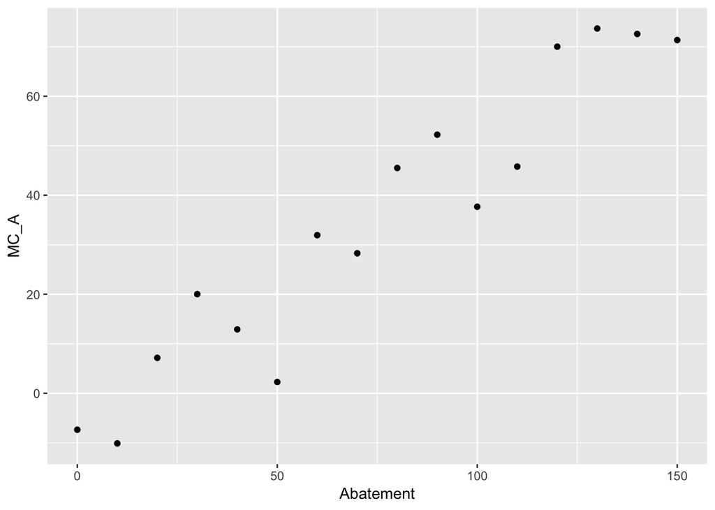

```r
#Marginal cost of abatement scatter plots
sector_A <- ggplot(carbon_abate, aes(x = Abatement, y = MC_A)) +
  geom_point()
sector_A
```

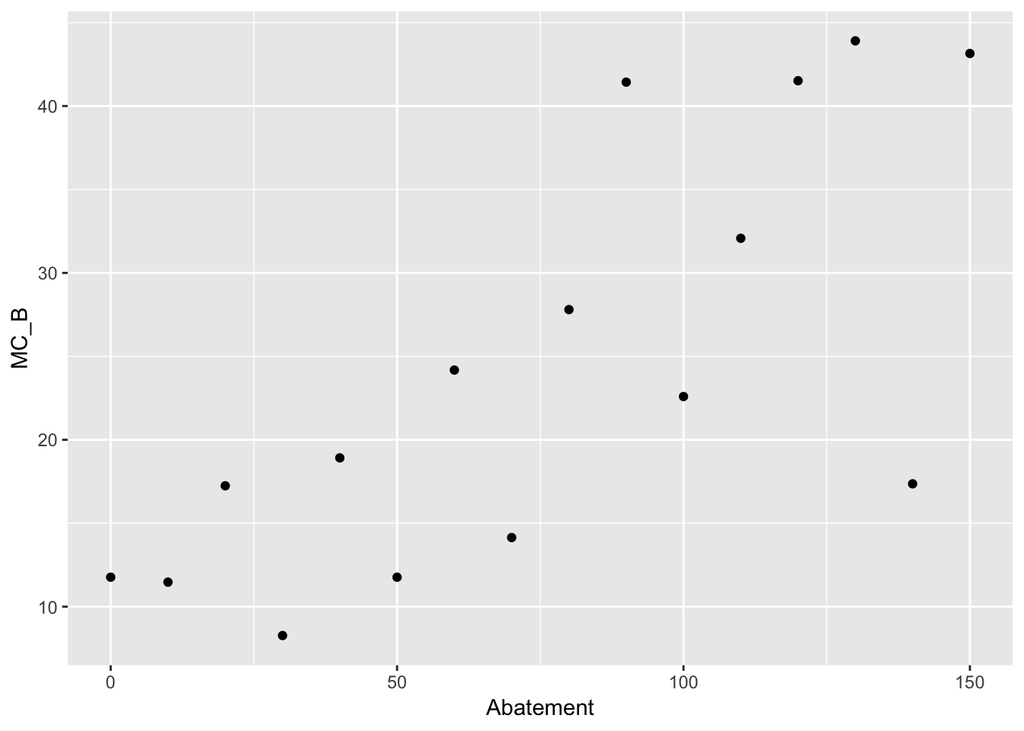

```r
sector_B <- ggplot(carbon_abate, aes(x = Abatement, y = MC_B)) +
  geom_point()
sector_B
```

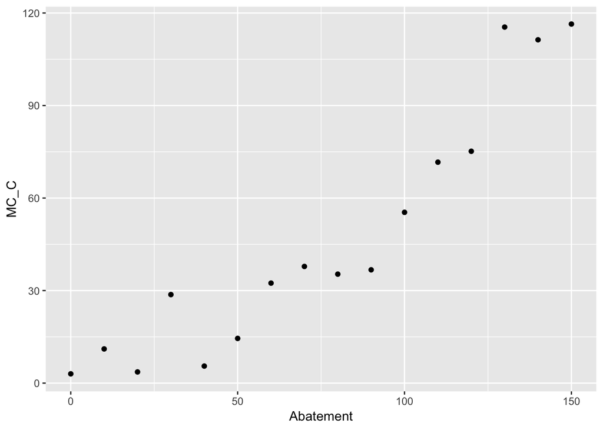

```r
sector_C <- ggplot(carbon_abate, aes(x = Abatement, y = MC_C)) +
  geom_point()
sector_C
```

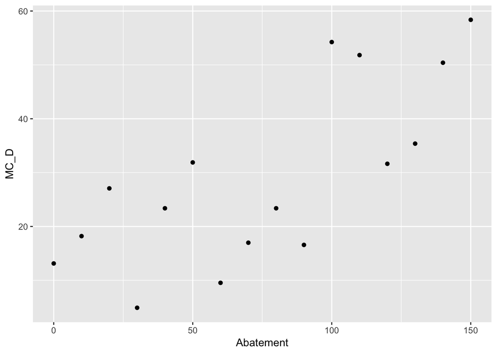

```r
sector_D <- ggplot(carbon_abate, aes(x = Abatement, y = MC_D)) +
  geom_point()
sector_D
```

# Question 1.

Write down a plausible functional form for the marginal cost of abatement for sector A. Use regression analysis to estimate the parameters of that function. Repeating this for sectors B, C, and D will give you a model of the marginal cost of abatement function for each sector. How well do your models fit the data for each sector? You may need to experiment with different functional forms. Produce a plot of the estimated marginal abatement cost functions in all four sectors (this plot should go in your memo).

## 1) Choose a functional form

Answer: Linear regression bc fuckkkk that shit

## 2) Determine marginal cost of abatement functions for each sector

```r
#MC Linear regressions
model_A <- lm(MC_A ~ Abatement, data = carbon_abate)
summary(model_A)
```

```
##
## Call:
## lm(formula = MC_A ~ Abatement, data = carbon_abate)
##
## Residuals:
##      Min       1Q   Median       3Q      Max
## -17.9221  -6.7176   0.8734   7.4986  11.3643
##
## Coefficients:
##             Estimate Std. Error t value Pr(>|t|)
## (Intercept) -8.64448    4.25720  -2.031   0.0617 .
## Abatement    0.57684    0.04836  11.928 1.01e-08 ***
## ---
## Signif. codes:  0 '***' 0.001 '**' 0.01 '*' 0.05 '.' 0.1 ' ' 1
##
## Residual standard error: 8.917 on 14 degrees of freedom
## Multiple R-squared:  0.9104, Adjusted R-squared:  0.904
## F-statistic: 142.3 on 1 and 14 DF,  p-value: 1.01e-08
```

```r
model_B <- lm(MC_B ~ Abatement, data = carbon_abate)
summary(model_B)
```

```
##
## Call:
## lm(formula = MC_B ~ Abatement, data = carbon_abate)
##
## Residuals:
##     Min      1Q  Median      3Q     Max
## -19.781  -6.702   2.049   3.968  14.226
##
## Coefficients:
##             Estimate Std. Error t value Pr(>|t|)
## (Intercept)  9.31770    4.09094   2.278 0.038966 *
## Abatement    0.19874    0.04647   4.277 0.000767 ***
## ---
## Signif. codes:  0 '***' 0.001 '**' 0.01 '*' 0.05 '.' 0.1 ' ' 1
##
## Residual standard error: 8.569 on 14 degrees of freedom
## Multiple R-squared:  0.5664, Adjusted R-squared:  0.5355
## F-statistic: 18.29 on 1 and 14 DF,  p-value: 0.0007672
```

```r
model_C <- lm(MC_C ~ Abatement, data = carbon_abate)
summary(model_C)
```

```
##
## Call:
## lm(formula = MC_C ~ Abatement, data = carbon_abate)
##
## Residuals:
##     Min      1Q  Median      3Q     Max
## -22.153 -11.773  -2.939  13.591  25.195
##
## Coefficients:
##              Estimate Std. Error t value Pr(>|t|)
## (Intercept) -11.65503    6.96282  -1.674    0.116
## Abatement     0.78383    0.07909   9.910 1.04e-07 ***
## ---
## Signif. codes:  0 '***' 0.001 '**' 0.01 '*' 0.05 '.' 0.1 ' ' 1
##
## Residual standard error: 14.58 on 14 degrees of freedom
## Multiple R-squared:  0.8752, Adjusted R-squared:  0.8663
## F-statistic: 98.21 on 1 and 14 DF,  p-value: 1.044e-07
```

```r
model_D <- lm(MC_D ~ Abatement, data = carbon_abate)
summary(model_D)
```

```
##
## Call:
## lm(formula = MC_D ~ Abatement, data = carbon_abate)
##
## Residuals:
##     Min      1Q  Median      3Q     Max
## -16.504  -9.654   3.368   9.329  18.558
##
## Coefficients:
##             Estimate Std. Error t value Pr(>|t|)
## (Intercept)  9.68751    5.60592   1.728  0.10595
## Abatement    0.25993    0.06368   4.082  0.00112 **
## ---
## Signif. codes:  0 '***' 0.001 '**' 0.01 '*' 0.05 '.' 0.1 ' ' 1
##
## Residual standard error: 11.74 on 14 degrees of freedom
## Multiple R-squared:  0.5434, Adjusted R-squared:  0.5108
## F-statistic: 16.66 on 1 and 14 DF,  p-value: 0.001121
```

```r
#MC Functions
MC_A_fxn <- function(Q) {(model_A$coefficients[2])*Q + model_A$coefficients[1]}
MC_B_fxn <- function(Q) {(model_B$coefficients[2])*Q + model_B$coefficients[1]}
MC_C_fxn <- function(Q) {(model_C$coefficients[2])*Q + model_C$coefficients[1]}
MC_D_fxn <- function(Q) {(model_D$coefficients[2])*Q + model_D$coefficients[1]}
```

## 3) How well does your model fit the data?

Answer: Close enough bitch

## 4) Produce a plot of the marginal abatement cost functions for all four sectors

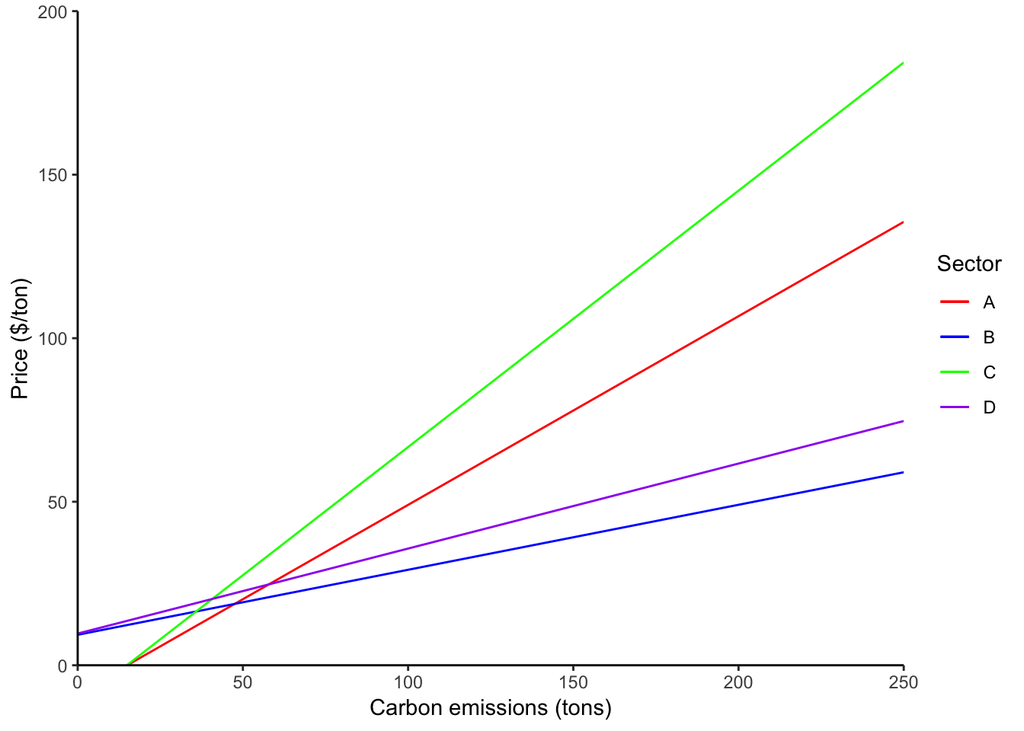

```r
#MC graph
MC_graph <- ggplot(data.frame(x=c(1, 250)), aes(x=x)) +
  stat_function(fun = MC_A_fxn, geom = "line", aes(color="A")) +
  stat_function(fun = MC_B_fxn, geom = "line", aes(color="B")) +
  stat_function(fun = MC_C_fxn, geom = "line", aes(color="C")) +
  stat_function(fun = MC_D_fxn, geom = "line", aes(color="D")) +
  xlab("Carbon emissions (tons)") +
  ylab("Price ($/ton)") +
  scale_x_continuous(expand = c(0,0), limits = c(0,250))+
  scale_y_continuous(expand = c(0,0), limits = c(0,200))+
  scale_color_manual(values = c(A="red", B="blue", C="green", D="purple"), name = "Sector")+
  theme_classic()
MC_graph
```

# Question 2.

Using these models and the current level of carbon emissions, derive each sector’s demand curve for carbon emissions. In other words, how much would each sector be willing to pay for the right to pollute the first unit, second unit, etc? Draw these demand curves on a graph. Which sector is willing to pay the most for the first unit of carbon emissions?

## 1) Demand curves for carbon emissions for each sector

```r
#Set initial emissions
Q_A_initial <- 180
Q_B_initial <- 200
Q_C_initial <- 220
Q_D_initial <- 300


#Price for each sector at their initial Q (i.e. the y intercept of the demand function)
demand_A_int <- (model_A$coefficients[1] + model_A$coefficients[2]*Q_A_initial)
demand_A_int #95.18706
```

```
## (Intercept)
##    95.18706
```

```r
demand_B_int <- (model_B$coefficients[1] + model_B$coefficients[2]*Q_B_initial)
demand_B_int #49.06656
```

```
## (Intercept)
##    49.06656
```

```r
demand_C_int <- (model_C$coefficients[1] + model_C$coefficients[2]*Q_C_initial)
demand_C_int #160.7868
```

```
## (Intercept)
##    160.7868
```

```r
demand_D_int <- (model_D$coefficients[1] + model_D$coefficients[2]*Q_D_initial)
demand_D_int #87.66577
```

```
## (Intercept)
##    87.66577
```

```r
#Slope of the demand function for each sector
demand_A_slope <- (demand_A_int/-Q_A_initial)
demand_A_slope # -0.528817
```

```
## (Intercept)
##   -0.528817
```

```r
demand_B_slope <- (demand_B_int/-Q_B_initial)
demand_B_slope # -0.2453328
```

```
## (Intercept)
##  -0.2453328
```

```r
demand_C_slope <- (demand_C_int/-Q_C_initial)
demand_C_slope # -0.7308492
```

```
## (Intercept)
##  -0.7308492
```

```r
demand_D_slope <- (demand_D_int/-Q_D_initial)
demand_D_slope # -0.2922192
```

```
## (Intercept)
##  -0.2922192
```

```r
#Final demand functions (price = slope*Q + intercept)
demand_A_fxn <- function(Q) {demand_A_slope*Q + demand_A_int}
demand_B_fxn <- function(Q) {demand_B_slope*Q + demand_B_int}
demand_C_fxn <- function(Q) {demand_C_slope*Q + demand_C_int}
demand_D_fxn <- function(Q) {demand_D_slope*Q + demand_D_int}
```

## 2) Graph of the demand curves

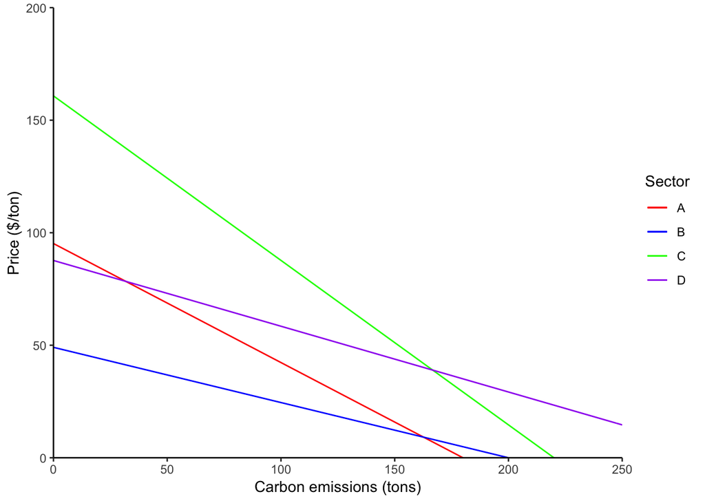

```r
#Demand graph
demand_graph <- ggplot(data.frame(x=c(1, 250)), aes(x=x)) +
  stat_function(fun = demand_A_fxn, geom = "line", aes(color="A")) +
  stat_function(fun = demand_B_fxn, geom = "line", aes(color="B")) +
  stat_function(fun = demand_C_fxn, geom = "line", aes(color="C")) +
  stat_function(fun = demand_D_fxn, geom = "line", aes(color="D")) +
  xlab("Carbon emissions (tons)") +
  ylab("Price ($/ton)") +
  scale_x_continuous(expand = c(0,0), limits = c(0,250))+
  scale_y_continuous(expand = c(0,0), limits = c(0,200))+
  theme_classic() +
  scale_color_manual(values = c(A="red", B="blue", C="green", D="purple"), name = "Sector")
demand_graph
```

## 3) Which sector is willing to pay the most for the first unit of carbon emissions?

# Question 3.

Now focus on country X (which contains sectors A, B, and C). Assume there are no “co-benefits” from carbon abatement (i.e. that there are no local pollutants that are affected by carbon abatement). Suppose to meet the Paris Accord commitments, country X needs to cut all carbon emissions in half. For each of the policy options listed below, derive: (1) The cost (or benefit) to each sector (2) The total cost of meeting the target in country X (3) The tax revenue generated

# A. Carbon cap

Each sector (A, B, and C) must cut its carbon emissions by 100 tons (thus reducing total emissions from 600 down to 300).

A: 180 tons –> 80 tons B: 200 tons –> 100 tons C: 220 tons –> 120 tons

## (1) The cost (or benefit) to each sector

```r
#Sector cost
cost_A_cap <- integrate(demand_A_fxn, 80, Q_A_initial)
cost_A_cap # 2644.085
```

```
## 2644.085 with absolute error < 2.9e-11
```

```r
cost_B_cap <- integrate(demand_B_fxn, 100, Q_B_initial)
cost_B_cap # 1226.664
```

```
## 1226.664 with absolute error < 1.4e-11
```

```r
cost_C_cap <- integrate(demand_C_fxn, 120, Q_C_initial)
cost_C_cap # 3654.246
```

```
## 3654.246 with absolute error < 4.1e-11
```

## (2) The total cost of meeting the target in country X

```r
#Total cost
cost_total_cap <- cost_A_cap[["value"]] + cost_B_cap[["value"]] + cost_C_cap[["value"]]
cost_total_cap # 7524.995
```

```
## [1] 7524.995
```

```r
#Total cost of the carbon cap policy is $7524.995
```

## (3) Tax revenue generated

```r
#Total tax revenue = $0
```